# Group 1 Midterm

Evelyn Campo, Xiao Qi, Nusrat Prithee, Roman Kosarzycki

2022-03-09

```r
tvdata <- data.frame(read.csv("tv_shows.csv"))
str(tvdata)
```

This step is to clear data, change some string data to number and some to factor.

```r
tvdata$IMDb<-gsub("/10","",as.character(tvdata$IMDb))
tvdata$Rotten.Tomatoes<-gsub("/100","",as.character(tvdata$Rotten.Tomatoes))
tvdata$IMDb<-as.double(tvdata$IMDb)
tvdata$Rotten.Tomatoes<-as.double(tvdata$Rotten.Tomatoes)

# total_plt <- tvdata$Netflix + tvdata$Hulu + tvdata$Prime.Video + tvdata$Disney.
# tvdata <- cbind(tvdata, total_plt)

tvdata$Netflix = factor(tvdata$Netflix)
tvdata$Hulu = factor(tvdata$Hulu)
tvdata$Prime.Video = factor(tvdata$Prime.Video)
tvdata$Disney. = factor(tvdata$Disney.)
tvdata$Age = factor(tvdata$Age)

str(tvdata)
#View(tvdata)
```

To analyze the score relationships between two platforms, we need to drop the rows that have no IMDb scores and no Rotten.Tomatoes scores. Meanwhile, the column of X, ID, Title and Type are useless, so we also drop these columns.

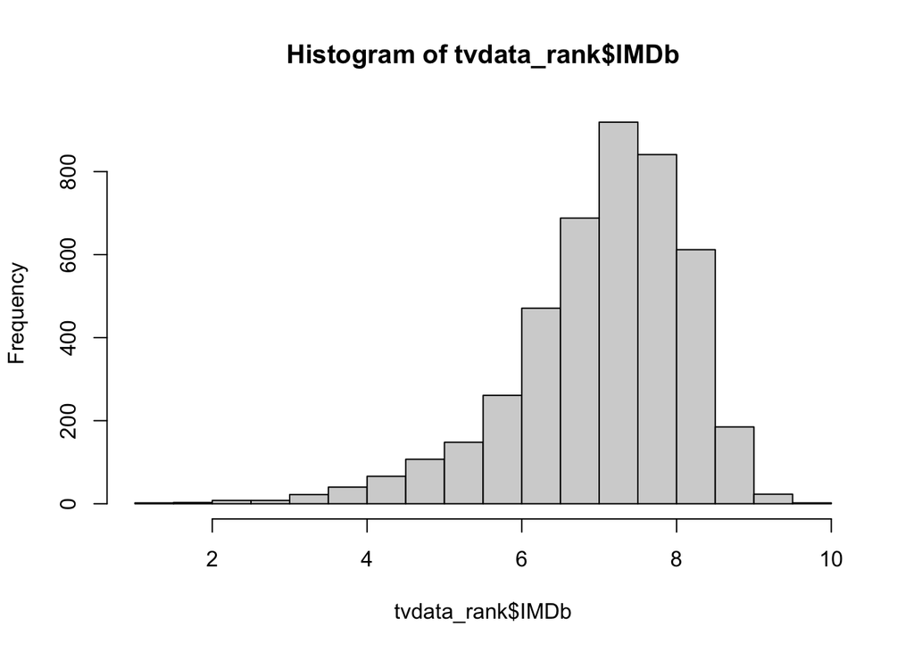

```r
tvdata_rank <- subset(tvdata, (!is.na(IMDb)) & (!is.na(Rotten.Tomatoes)))
tvdata_rank = subset(tvdata_rank, select = -c(X, ID, Title, Type))
str(tvdata_rank)

hist(tvdata_rank$IMDb,breaks=20)
```

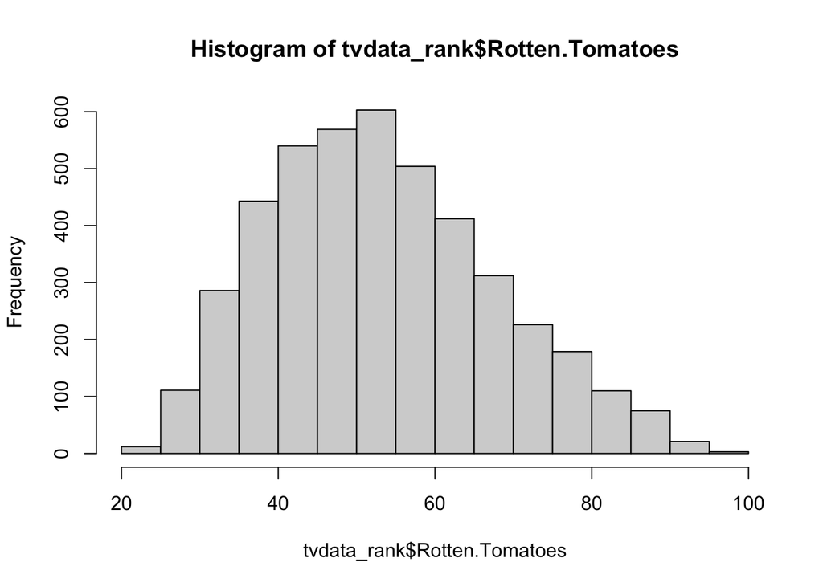

```r
hist(tvdata_rank$Rotten.Tomatoes,breaks=20)
```

Make a pairs() plot with all the variables (quantitative and qualitative).

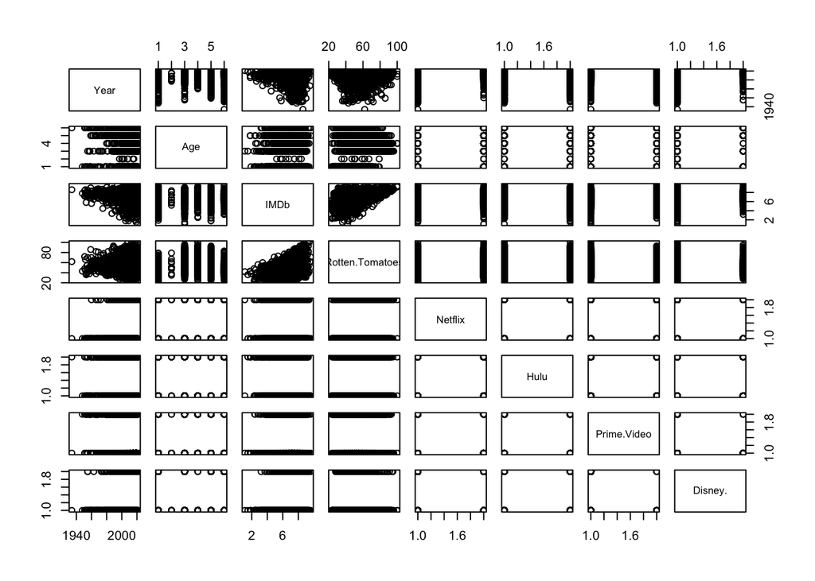

```r
loadPkg("lattice") # lattice and ggplot2 combined allow us to use the "pairs" function below
pairs(tvdata_rank)
```

Make a corrplot() with only the numerical variables.

[figure not shown]

```r
loadPkg("corrplot")
tvdata_rank_num = subset(tvdata_rank, select = -c(Age, Netflix, Hulu, Prime.Video, Disney.))

cor_tvdata = cor(tvdata_rank_num)

corrplot(cor_tvdata, method = "number", type="upper")
```

```r
# corrplot.mixed(cor_tvdata)
```

By using the variable Rotten.Tomatoes only, build a linear model with 1 independent variable to predict the IMDb.

```r
model1 = lm(IMDb ~ Rotten.Tomatoes, data=tvdata_rank)
sum_md1 = summary(model1) # also for later use on inline codes
sum_md1
```

```
##
## Call:
## lm(formula = IMDb ~ Rotten.Tomatoes, data = tvdata_rank)
##
## Residuals:
##    Min     1Q Median     3Q    Max
## -5.562 -0.495  0.087  0.628  2.746
##
## Coefficients:
##                 Estimate Std. Error t value Pr(>|t|)
## (Intercept)      5.15419    0.05785    89.1   <2e-16 ***
## Rotten.Tomatoes  0.03590    0.00104    34.6   <2e-16 ***
## ---
## Signif. codes:  0 '***' 0.001 '**' 0.01 '*' 0.05 '.' 0.1 ' ' 1
##
## Residual standard error: 0.989 on 4404 degrees of freedom
## Multiple R-squared:  0.213,  Adjusted R-squared:  0.213
## F-statistic: 1.19e+03 on 1 and 4404 DF,  p-value: <2e-16
```

```r
xkabledply(model1, title = paste("Model (num):", format(formula(model1)) ) )
```

Model (num): IMDb ~ Rotten.Tomatoes

|  | Estimate | Std. Error | t value | Pr(>\|t\|) |
| --- | --- | --- | --- | --- |
| (Intercept) | 5.1542 | 0.0579 | 89.1 | 0 |
| Rotten.Tomatoes | 0.0359 | 0.0010 | 34.6 | 0 |

```r
# xkablevif(model1)
```

```r
model2 = lm(IMDb ~ ., data=tvdata_rank)
sum_md2 = summary(model2) # also for later use on inline codes
sum_md2
```

[output not shown]

We can find that the adjusted correlation coefficient increases, but some variables are not significant, so try to drop it.

```r
table(tvdata_rank$Age)
```

[output not shown]

The result is that for age13+, there are only 9 shows. Too little sample cause a large p-value. So we need to drop the factor of Age13+. We also drop Netflix, Prime.Video, Disney., because the p-values of these variables are not significant.

```r
tvdata_rank_no13 <- subset(tvdata_rank, Age!="13+")
tvdata_rank_no13 = subset(tvdata_rank_no13, select = -c(Netflix, Prime.Video, Disney.))
```

And then me make the third model as follow.

```r
model3 = lm(IMDb ~ ., data=tvdata_rank_no13)
sum_md3 = summary(model3) # also for later use on inline codes
sum_md3
```

[output not shown]

We can find that all variables are significant and the adjusted r-squared is 0.246, much higher than the simple linear regression.

```r
#vif_md3 = faraway::vif(model3)
#vif_md3

xkabledply(model3, title = paste("Model (num):", format(formula(model3)) ) )
```

Model (num): IMDb ~ Year + Age + Rotten.Tomatoes + Hulu

|  | Estimate | Std. Error | t value | Pr(>\|t\|) |
| --- | --- | --- | --- | --- |
| (Intercept) | 21.6813 | 3.0357 | 7.14 | 0 |
| Year | -0.0082 | 0.0015 | -5.46 | 0 |
| Age16+ | -0.3775 | 0.0473 | -7.97 | 0 |
| Age18+ | -0.4418 | 0.0496 | -8.91 | 0 |
| Age7+ | -0.4364 | 0.0466 | -9.36 | 0 |
| Ageall | -0.3467 | 0.0514 | -6.74 | 0 |
| Rotten.Tomatoes | 0.0427 | 0.0012 | 35.11 | 0 |
| Hulu1 | -0.2088 | 0.0331 | -6.32 | 0 |

```r
xkablevif(model3)
```

VIFs of the model

| Age16+ | Age18+ | Age7+ | Ageall | Hulu1 | Rotten.Tomatoes | Year |
| --- | --- | --- | --- | --- | --- | --- |
| 1.11 | 1.83 | 1.8 | 1.55 | 1.32 | 1.43 | 1.12 |

```r
# aovresult <- anova(model1, model2, model3)
# aovresult
```

This is an Error because “models were not all fitted to the same size of dataset”, so we redo the simple linear regression using tvdata_rank_no13 as model4.

```r
model4 = lm(IMDb ~ Rotten.Tomatoes, data=tvdata_rank_no13)
sum_md4 = summary(model4) # also for later use on inline codes
sum_md4
```

```
##
## Call:
## lm(formula = IMDb ~ Rotten.Tomatoes, data = tvdata_rank_no13)
##
## Residuals:
##    Min     1Q Median     3Q    Max
## -5.563 -0.493  0.088  0.627  2.744
##
## Coefficients:
##                 Estimate Std. Error t value Pr(>|t|)
## (Intercept)      5.15828    0.05793    89.0   <2e-16 ***
## Rotten.Tomatoes  0.03584    0.00104    34.5   <2e-16 ***
## ---
## Signif. codes:  0 '***' 0.001 '**' 0.01 '*' 0.05 '.' 0.1 ' ' 1
##
## Residual standard error: 0.99 on 4395 degrees of freedom
## Multiple R-squared:  0.213,  Adjusted R-squared:  0.212
## F-statistic: 1.19e+03 on 1 and 4395 DF,  p-value: <2e-16
```

```r
xkabledply(model4, title = paste("Model (num):", format(formula(model4)) ) )
```

Model (num): IMDb ~ Rotten.Tomatoes

|  | Estimate | Std. Error | t value | Pr(>\|t\|) |
| --- | --- | --- | --- | --- |
| (Intercept) | 5.1583 | 0.0579 | 89.0 | 0 |
| Rotten.Tomatoes | 0.0358 | 0.0010 | 34.4 | 0 |

```r
# xkablevif(model4)
```

The concepts above can be extended naturally to models with interactions between numeric and factor variables.

```r
model5 = lm(IMDb ~ . + Rotten.Tomatoes:Age, data=tvdata_rank_no13)
sum_md5 = summary(model5) # also for later use on inline codes
sum_md5
```

```
##
## Call:
## lm(formula = IMDb ~ . + Rotten.Tomatoes:Age, data = tvdata_rank_no13)
##
## Residuals:
##    Min     1Q Median     3Q    Max
## -5.453 -0.493  0.072  0.607  2.799
##
## Coefficients:
##                         Estimate Std. Error t value Pr(>|t|)
## (Intercept)            23.464467   3.068632    7.65  2.5e-14 ***
## Year                   -0.009186   0.001525   -6.02  1.9e-09 ***
## Age16+                  0.005813   0.189196    0.03   0.9755
## Age18+                 -0.453837   0.199101   -2.28   0.0227 *
## Age7+                  -0.516497   0.198813   -2.60   0.0094 **
## Ageall                  0.609364   0.235339    2.59   0.0096 **
## Rotten.Tomatoes         0.046692   0.002810   16.62  < 2e-16 ***
## Hulu1                  -0.209429   0.033037   -6.34  2.5e-10 ***
## Age16+:Rotten.Tomatoes -0.007472   0.003620   -2.06   0.0391 *
## Age18+:Rotten.Tomatoes -0.001010   0.003700   -0.27   0.7849
## Age7+:Rotten.Tomatoes   0.000526   0.003932    0.13   0.8936
## Ageall:Rotten.Tomatoes -0.020359   0.004954   -4.11  4.0e-05 ***
## ---
## Signif. codes:  0 '***' 0.001 '**' 0.01 '*' 0.05 '.' 0.1 ' ' 1
##
## Residual standard error: 0.966 on 4385 degrees of freedom
## Multiple R-squared:  0.251,  Adjusted R-squared:  0.249
## F-statistic:  134 on 11 and 4385 DF,  p-value: <2e-16
```

```r
xkabledply(model5, title = paste("Model (num):", format(formula(model5)) ) )
```

Model (num): IMDb ~ Year + Age + Rotten.Tomatoes + Hulu + Rotten.Tomatoes:Age

|  | Estimate | Std. Error | t value | Pr(>\|t\|) |
| --- | --- | --- | --- | --- |
| (Intercept) | 23.4645 | 3.0686 | 7.6466 | 0.0000 |
| Year | -0.0092 | 0.0015 | -6.0229 | 0.0000 |
| Age16+ | 0.0058 | 0.1892 | 0.0307 | 0.9755 |
| Age18+ | -0.4538 | 0.1991 | -2.2794 | 0.0227 |
| Age7+ | -0.5165 | 0.1988 | -2.5979 | 0.0094 |
| Ageall | 0.6094 | 0.2353 | 2.5893 | 0.0096 |
| Rotten.Tomatoes | 0.0467 | 0.0028 | 16.6182 | 0.0000 |
| Hulu1 | -0.2094 | 0.0330 | -6.3392 | 0.0000 |
| Age16+:Rotten.Tomatoes | -0.0075 | 0.0036 | -2.0640 | 0.0391 |
| Age18+:Rotten.Tomatoes | -0.0010 | 0.0037 | -0.2730 | 0.7849 |
| Age7+:Rotten.Tomatoes | 0.0005 | 0.0039 | 0.1337 | 0.8936 |
| Ageall:Rotten.Tomatoes | -0.0204 | 0.0050 | -4.1094 | 0.0000 |

```r
# xkablevif(model5)
```

Compared with these three models:

```r
aovresult1 <- anova(model4, model3, model5)
str(aovresult1)
```

```
## Classes 'anova' and 'data.frame':    3 obs. of  6 variables:
##  $ Res.Df   : num  4395 4389 4385
##  $ RSS      : num  4304 4117 4093
##  $ Df       : num  NA 6 4
##  $ Sum of Sq: num  NA 186.9 23.4
##  $ F        : num  NA 33.36 6.26
##  $ Pr(>F)   : num  NA 1.45e-39 5.09e-05
##  - attr(*, "heading")= chr [1:2] "Analysis of Variance Table\n" "Model 1: IMDb ~ Rotten.Tomatoes\nModel 2: IMDb ~ Year + Age + Rotten.Tomatoes + Hulu\nModel 3: IMDb ~ Year + Ag"| __truncated__
```

```r
xkabledply(aovresult1, title = "ANOVA comparison between the models")
```

ANOVA comparison between the models

| Res.Df | RSS | Df | Sum of Sq | F | Pr(>F) |
| --- | --- | --- | --- | --- | --- |
| 4395 | 4304 | NA | NA | NA | NA |
| 4389 | 4117 | 6 | 186.9 | 33.36 | 0e+00 |
| 4385 | 4093 | 4 | 23.4 | 6.26 | 1e-04 |

Add one interaction, full model seems quite nice (although it’s still a weak correlation).

IMDb = 23.464467 + -0.009186 * Year + 0.046692 * Rotten.Tomatoes + -0.209429 * Hulu + (-0.516497 + 0.000526 * Rotten.Tomatoes) * Age7+ + (0.005813 + -0.007472 * Rotten.Tomatoes) * Age16+ + (-0.453837 + -0.001010 * Rotten.Tomatoes) * Age18+ + (0.609364 + -0.020359 * Rotten.Tomatoes) * Ageall